# Проект

Валентин Копылов

10.06.2019

# Исследование:

## Выяснение факторов, влияющих на вероятность использования велосипеда в городе Москве

### Предварительные гипотезы:

1. Возраст респондента оказывает отрицательное влияние на вероятность катания на велосипеде
2. Плохая инфраструктура оказывает негативное влияние на веротность катания на велосипеде
3. Опасность поездки оказывает негативное влияние на вероятность катания на велосипеде

### База данных:

Гугл-опрос: https://docs.google.com/forms/d/1aIwLqaRPXesWKB_azNFBsdzKjs2zFic4BPOISQQOiKA/edit

Я создал свою гугл-опрос форму и кинул ее в множество Facebook сообществ, связанных с районным объединением, откуда я и получил своих респондентов. Список районных групп:

- [Гагаринский район](https://www.facebook.com/groups/sovetgagarin/)
- [Обручевский район](https://www.facebook.com/groups/obruchevskiy/)
- [Тропарево-Никулино соседи](https://www.facebook.com/groups/tropnik/)
- [Фили Давыдково. Соседи](https://www.facebook.com/groups/249145022159351/)
- [РАМЕНКИ](https://www.facebook.com/groups/Ramenki/)
- [Независимые Хамовники](https://www.facebook.com/groups/131561047463457/)
- [Район Филевский парк](https://www.facebook.com/groups/filipark/)
- [Хорошево-мневники / Щукино Соседи](https://www.facebook.com/groups/1441778869409039/)
- [Академический район](https://www.facebook.com/groups/akademichesky/)
- [Лефортово](https://www.facebook.com/groups/Lefortovo/)
- [Сокольники](https://www.facebook.com/groups/sokolniki/)
- [Чертаново Центральное](https://www.facebook.com/groups/chertanovocentr/)
- Басманный LIVE/соседи

В дальнейшем, я выгрузил данные с сайта в формате csv.

```r
library(psych)
library(rebus)
library(stringr)
library(jtools)
library(huxtable)
library(ggstance)
library(ggplot2)
library(gridExtra)
library(stargazer)
library(Amelia)
library(dplyr)
```

```r
df <- read.csv('velo2.csv')
```

Переименуем все переменные для удобства взаимодействовать:

```r
colnames(df) <- c('time', 'sex', 'age', 'education', 'district', 'work_study', 'bicycle', 'experience_bicycle',  'velobike',
                  'not_velobike',  'aim_bike', 'bike_plus_others', 'personal_bike', 'velobike_station', 'personal_auto',
                  'how_far_work', 'bike_danger', 'infrustructure_bike', 'bike_work_parking', 'bike_home_parking',
                  'bike_importance','bike_positive', 'what_is_bicycle')
```

Обработаем возраст

```r
df$age <- as.character(df$age)
df$age[198] <- '30'
df$age <- as.numeric(df$age)
df %>% filter(age < 100) -> df
summary(df$age)
```

```
##    Min. 1st Qu.  Median    Mean 3rd Qu.    Max.
##   13.00   33.00   38.00   38.26   44.00   69.00
```

Перекодируем пол:

```r
df$sex <- as.character(recode_factor(df$sex,
                                   'Мужской' = '0',
                                   'Женский' = '1',
                                   .default = NA_character_))
df$sex <- as.factor(df$sex)
summary(df$sex)
```

```
##    0    1 NA's
##  169  389    6
```

Перекодируем образование:

```r
levels(df$education) <- c('higher', 'higher, phd', 'uncomplete higher', 'uncomplete middle', 'middle common', 'middle special')
summary(df$education)
```

```
##            higher       higher, phd uncomplete higher uncomplete middle
##               389                80                59                 3
##     middle common    middle special
##                15                18
```

Разберемся с районами!

```r
df$district <- as.character(df$district)

df$district <- tolower(df$district)
df$district[str_detect(df$district, pattern = ' '  %R% END)] <- str_replace_all(df$district[str_detect(df$district, pattern = ' '  %R% END)], " ", "")

df$district[str_detect(df$district, pattern = START %R% 'алексе')] <- 'алексеевский'
df$district[str_detect(df$district, pattern = START %R% 'красносе')] <- 'красносельский'

df$district[str_detect(df$district, pattern = START %R% 'западный')] <- 'зао'

df$district[str_detect(df$district, pattern = START %R% 'изма')] <- 'измайлово'

df$district[str_detect(df$district, pattern = START %R% 'юг')] <- 'юзао'

df$district[str_detect(df$district, pattern = 'ушки'  %R% END)] <- 'черемушки'

df$district[str_detect(df$district, pattern = START %R% 'хорош')] <- 'хорошево-мневники'
df$district[str_detect(df$district, pattern = START %R% 'мнёвники')] <- 'хорошево-мневники'

df$district[str_detect(df$district, pattern = START %R% 'хамовн')] <- 'хамовники'

df$district[str_detect(df$district, pattern = START %R% 'фили')] <- 'фили-давыдково'
df$district[str_detect(df$district, pattern = START %R% 'давыдково')] <- 'фили-давыдково'

df$district[str_detect(df$district, pattern = 'никул')] <- 'тропарево-никулино'
df$district[str_detect(df$district, pattern = 'тропар')] <- 'тропарево-никулино'

df$district[str_detect(df$district, pattern = START %R% 'нагатино')] <- 'нагатино-садовники'

df$district[str_detect(df$district, pattern = START %R% 'цаоб')] <- 'басманный'
df$district[str_detect(df$district, pattern = 'басм')] <- 'басманный'

df$district[str_detect(df$district, pattern = 'бутово')] <- 'бутово'

df$district[str_detect(df$district, pattern = 'плый')] <- 'теплый стан'

df$district[str_detect(df$district, pattern = 'цао')] <- 'цао'
df$district[str_detect(df$district, pattern = 'центр')] <- 'цао'


df$district[str_detect(df$district, pattern = ', хоро')] <- 'сокол'

df$district[str_detect(df$district, pattern = 'гагарин')] <- 'гагаринский'

df$district[str_detect(df$district, pattern = 'горы')] <- 'гагаринский'

df$district[str_detect(df$district, pattern = 'академ')] <- 'академический'
df$district[str_detect(df$district, pattern = 'вьетнам')] <- 'академический' # это мем
df$district[str_detect(df$district, pattern = 'сайгон')] <- 'академический' # это тоже мем

df$district[str_detect(df$district, pattern = 'кунце')] <- 'кунцево'

df$district[str_detect(df$district, pattern = 'парк')] <- 'филевский парк'

df$district[str_detect(df$district, pattern = 'иван')] <- 'ивановское'

df$district[str_detect(df$district, pattern = 'очаково')] <- 'очаково-матвеевское'

# интересуют московские районы
df$district[str_detect(df$district, pattern = '19')] <- NA
df$district[str_detect(df$district, pattern = 'москов')] <- NA
df$district[str_detect(df$district, pattern = 'москва')] <- NA
df$district[str_detect(df$district, pattern = 'замкадье')] <- NA
df$district[str_detect(df$district, pattern = 'балашиха')] <- NA
df$district[str_detect(df$district, pattern = 'истринский')] <- NA
df$district[str_detect(df$district, pattern = 'курортный')] <- NA
df$district[str_detect(df$district, pattern = 'дело')] <- NA
df$district[str_detect(df$district, pattern = 'курортный')] <- NA
df$district <- as.factor(df$district)

summary(df$district)
```

```
##        академический         алексеевский                арбат
##                   20                    2                    2
##             аэропорт            басманный           бауманская
##                    1                   39                    1
##    бирюлево западное               бутово            бутырский
##                    1                    3                    1
##   восточное дегунино      выхино жулебино          гагаринский
##                    1                    1                   51
##          головинский            гольяново          даниловский
##                    1                    2                    1
##             дегунино              донской         дорогомилово
##                    1                    2                    1
##        замоскворечье                  зао    западное дегунино
##                    3                   11                    1
##               зюзино            зябликово           ивановское
##                    2                    1                    1
##            измайлово              капотня             коньково
##                    4                    1                    4
##              коптево             котловка       красносельский
##                    1                    2                    3
##           крылатское              кунцево              куркино
##                    5                    5                    1
##            лефортово        ломоносовский              люблино
##                    9                    6                    2
##          матвеевское           медведково            мещанский
##                    1                    1                    2
##            можайский          молжаниново   нагатино-садовники
##                    2                    1                    2
##          новогиреево           новокосино          обручевский
##                    1                    2                   24
##             отрадное  очаково-матвеевское               перово
##                    2                    2                    1
## покровское-стрешнево       преображенское          пресненский
##                    1                    3                    2
## проспект вернадского              раменки                  сао
##                    2                   40                    1
##                 свао   северное измайлово                 сзао
##                    1                    1                    3
##                сокол           сокольники             солнцево
##                    3                   18                    2
##             строгино            таганский             тверской
##                    3                    3                    1
##         текстильщики          теплый стан   тропарево-никулино
##                    2                    5                   55
##               тушино       филевский парк       фили-давыдково
##                    2                   14                   34
##            хамовники    хорошево-мневники                  цао
##                   27                   36                   14
##            черемушки            чертаново               щукино
##                    3                    3                   14
##                 ювао                 юзао             якиманка
##                    1                   14                    3
##          ярославский                 NA's
##                    1                   18
```

Преобразуем переменую занятости

```r
df$work_study <- as.character(df$work_study)

df$work_study[str_detect(df$work_study, pattern = 'екр')] <- 'Декрет'
df$work_study[str_detect(df$work_study, pattern = or('Дом',"Я безработный", 'отпу', 'Рен', 'Не р', 'пуск', 'хоз'))] <- 'Безработный'
df$work_study[str_detect(df$work_study, pattern = 'енси')] <- 'Пенсионер'
df$work_study[str_detect(df$work_study, pattern = or('Пре',"Я работаю", 'аботаю', 'риланс'))] <- 'Работает'
df$work_study[str_detect(df$work_study, pattern = 'Я учусь')] <- 'Учится'
df$work_study <- as.factor(df$work_study)
summary(df$work_study)
```

```
## Безработный      Декрет   Пенсионер    Работает      Учится
##          56          15           9         436          48
```

Преобразуем бинарные переменные:

Зависимая переменная анализа:

```r
df$bicycle <- as.factor(as.character(recode_factor(df$bicycle,
                            'Да' = '1',
                            'Нет' = '0', .default = NA_character_)))
summary(df$bicycle)
```

```
##   0   1
## 260 304
```

```r
levels(df$experience_bicycle)[1] <- NA
summary(df$experience_bicycle)
```

```
##   Более 10 лет     до 1  года  от 1 до 5 лет от 5 до 10 лет           NA's
##            286              2             10              6            260
```

```r
levels(df$velobike)[1] <- NA
df$velobike <- as.factor(as.character(recode_factor(df$velobike,
                                                   'Да, пользуюсь' = '1',
                                                   'Нет, не пользуюсь' = '0', .default = NA_character_)))
summary(df$velobike)
```

```
##    0    1 NA's
##  232   72  260
```

```r
levels(df$not_velobike)[1] <- NA
df$not_velobike <- as.factor(as.character(recode_factor(df$not_velobike,
                                                    'Да, пользуюсь' = '1',
                                                    'Нет, не пользуюсь' = '0', .default = NA_character_)))
summary(df$not_velobike)
```

```
##    0    1 NA's
##  282   22  260
```

```r
levels(df$aim_bike)[1] <- NA

levels(df$bike_plus_others)[1] <- NA
df$bike_plus_others <- as.factor(as.character(recode_factor(df$bike_plus_others,
                                                        'Да' = '1',
                                                        'Нет' = '0', .default = NA_character_)))
summary(df$bike_plus_others)
```

```
##    0    1 NA's
##  166  138  260
```

```r
df$personal_bike <- as.factor(as.character(recode_factor(df$personal_bike,
                                                        'Да' = '1',
                                                        'Нет' = '0', .default = NA_character_)))
summary(df$personal_bike)
```

```
##   0   1
## 207 357
```

```r
df$velobike_station <- as.factor(as.character(recode_factor(df$velobike_station,
                                                         'Да, есть' = '1',
                                                         'Нет' = '0', .default = NA_character_)))
summary(df$velobike_station)
```

```
##   0   1
## 266 298
```

```r
df$personal_auto <- as.factor(as.character(recode_factor(df$personal_auto,
                                                            'Да, есть' = '1',
                                                            'Нет' = '0', .default = NA_character_)))
summary(df$personal_auto)
```

```
##   0   1
## 190 374
```

```r
df$how_far_work <- recode_factor(df$how_far_work,
                                 'Более 10 километров' = '>10',
                                 'Менее 2 километров' = '<2',
                                 'От 2 до 5 километров' = '2<x<5',
                                 'От 5 до 10 километров' = '5<x<10',
                                 .default = NA_character_)
summary(df$how_far_work)
```

```
##    >10     <2  2<x<5 5<x<10
##    238     70     99    157
```

```r
summary(df$bike_danger)
```

```
##    Min. 1st Qu.  Median    Mean 3rd Qu.    Max.
##   1.000   6.000   8.000   7.177   9.000  10.000
```

```r
summary(df$infrustructure_bike)
```

```
##    Min. 1st Qu.  Median    Mean 3rd Qu.    Max.
##   1.000   1.000   3.000   3.417   5.000  10.000
```

```r
summary(df$bike_work_parking)
```

```
##    Min. 1st Qu.  Median    Mean 3rd Qu.    Max.
##   1.000   1.000   5.000   5.245   9.000  10.000
```

```r
summary(df$bike_home_parking)
```

```
##    Min. 1st Qu.  Median    Mean 3rd Qu.    Max.
##   1.000   1.000   2.000   3.372   5.000  10.000
```

```r
summary(df$bike_importance)
```

```
##    Min. 1st Qu.  Median    Mean 3rd Qu.    Max.
##   1.000   2.000   5.000   5.133   8.000  10.000
```

```r
summary(df$bike_positive)
```

```
##    Min. 1st Qu.  Median    Mean 3rd Qu.    Max.
##   1.000   4.000   7.000   6.363  10.000  10.000
```

```r
df$time <- as.character(df$time)

what_is_bike <- as.character(df$what_is_bicycle)
```

```r
summary(df)
```

```
##      time             sex           age                    education
##  Length:564         0   :169   Min.   :13.00   higher           :389
##  Class :character   1   :389   1st Qu.:33.00   higher, phd      : 80
##  Mode  :character   NA's:  6   Median :38.00   uncomplete higher: 59
##                                Mean   :38.26   uncomplete middle:  3
##                                3rd Qu.:44.00   middle common    : 15
##                                Max.   :69.00   middle special   : 18
##
##                district         work_study  bicycle
##  тропарево-никулино: 55   Безработный: 56   0:260
##  гагаринский       : 51   Декрет     : 15   1:304
##  раменки           : 40   Пенсионер  :  9
##  басманный         : 39   Работает   :436
##  хорошево-мневники : 36   Учится     : 48
##  (Other)           :325
##  NA's              : 18
##       experience_bicycle velobike   not_velobike
##  Более 10 лет  :286      0   :232   0   :282
##  до 1  года    :  2      1   : 72   1   : 22
##  от 1 до 5 лет : 10      NA's:260   NA's:260
##  от 5 до 10 лет:  6
##  NA's          :260
##
##
##                                                                                        aim_bike
##  Способ проведения досуга                                                                  :168
##  Способ проведения досуга;Поездка на работу (и с работы)                                   : 34
##  Способ проведения досуга;Поездка на работу (и с работы);Поручения и личные встречи;Шоппинг: 18
##  Способ проведения досуга;Поездка на работу (и с работы);Поручения и личные встречи        : 13
##  Поездка на работу (и с работы)                                                            : 12
##  (Other)                                                                                   : 59
##  NA's                                                                                      :260
##  bike_plus_others personal_bike velobike_station personal_auto
##  0   :166         0:207         0:266            0:190
##  1   :138         1:357         1:298            1:374
##  NA's:260
##
##
##
##
```

[output cut: 9 more lines]

```
##  Min.   : 1.000    Min.   : 1.000   Min.   : 1.000
##  1st Qu.: 1.000    1st Qu.: 2.000   1st Qu.: 4.000
##  Median : 2.000    Median : 5.000   Median : 7.000
##  Mean   : 3.372    Mean   : 5.133   Mean   : 6.363
##  3rd Qu.: 5.000    3rd Qu.: 8.000   3rd Qu.:10.000
##  Max.   :10.000    Max.   :10.000   Max.   :10.000
##
##                what_is_bicycle
##                        :137
##  Развлечение           : 15
##  Средство передвижения : 12
##  Спорт                 : 11
##  Средство передвижения : 10
##  Отдых                 :  9
##  (Other)               :370
```

```r
describe(df)
```

| vars | n | mean | sd | median | trimmed | mad | min | max | range | skew | kurtosis | se |
| --- | --- | --- | --- | --- | --- | --- | --- | --- | --- | --- | --- | --- |
| 1 | 564 | NaN |  |  | NaN |  | Inf | -Inf | -Inf |  |  |  |
| 2 | 558 | 1.7 | 0.46 | 2 | 1.75 | 0 | 1 | 2 | 1 | -0.856 | -1.27 | 0.0195 |
| 3 | 564 | 38.3 | 9.91 | 38 | 38.3 | 8.9 | 13 | 69 | 56 | 0.06 | 0.175 | 0.417 |
| 4 | 564 | 1.63 | 1.2 | 1 | 1.35 | 0 | 1 | 6 | 5 | 2.24 | 4.63 | 0.0504 |
| 5 | 546 | 46.1 | 25.6 | 53 | 47.8 | 26.7 | 1 | 79 | 78 | -0.517 | -1.3 | 1.09 |
| 6 | 564 | 3.72 | 1.01 | 4 | 3.91 | 0 | 1 | 5 | 4 | -1.87 | 2.62 | 0.0426 |
| 7 | 564 | 1.54 | 0.499 | 2 | 1.55 | 0 | 1 | 2 | 1 | -0.156 | -1.98 | 0.021 |
| 8 | 304 | 1.13 | 0.547 | 1 | 1 | 0 | 1 | 4 | 3 | 4.16 | 16.4 | 0.0314 |
| 9 | 304 | 1.24 | 0.426 | 1 | 1.17 | 0 | 1 | 2 | 1 | 1.23 | -0.484 | 0.0244 |
| 10 | 304 | 1.07 | 0.26 | 1 | 1 | 0 | 1 | 2 | 1 | 3.28 | 8.82 | 0.0149 |
| 11 | 304 | 17.9 | 7.16 | 15 | 17.3 | 0 | 1 | 39 | 38 | 0.804 | 1.15 | 0.411 |
| 12 | 304 | 1.45 | 0.499 | 1 | 1.44 | 0 | 1 | 2 | 1 | 0.184 | -1.97 | 0.0286 |
| 13 | 564 | 1.63 | 0.482 | 2 | 1.67 | 0 | 1 | 2 | 1 | -0.55 | -1.7 | 0.0203 |
| 14 | 564 | 1.53 | 0.5 | 2 | 1.54 | 0 | 1 | 2 | 1 | -0.113 | -1.99 | 0.021 |
| 15 | 564 | 1.66 | 0.473 | 2 | 1.7 | 0 | 1 | 2 | 1 | -0.688 | -1.53 | 0.0199 |
| 16 | 564 | 2.31 | 1.27 | 2 | 2.26 | 1.48 | 1 | 4 | 3 | 0.218 | -1.64 | 0.0536 |
| 17 | 564 | 7.18 | 2.42 | 8 | 7.44 | 2.97 | 1 | 10 | 9 | -0.686 | -0.345 | 0.102 |
| 18 | 564 | 3.42 | 2.65 | 3 | 3.02 | 2.97 | 1 | 10 | 9 | 0.957 | -0.129 | 0.112 |
| 19 | 564 | 5.24 | 3.53 | 5 | 5.18 | 5.93 | 1 | 10 | 9 | 0.12 | -1.57 | 0.149 |
| 20 | 564 | 3.37 | 3.09 | 2 | 2.86 | 1.48 | 1 | 10 | 9 | 1.08 | -0.266 | 0.13 |
| 21 | 564 | 5.13 | 3.21 | 5 | 5.04 | 4.45 | 1 | 10 | 9 | 0.132 | -1.34 | 0.135 |
| 22 | 564 | 6.36 | 3.27 | 7 | 6.58 | 4.45 | 1 | 10 | 9 | -0.437 | -1.23 | 0.138 |
| 23 | 564 | 132 | 109 | 129 | 125 | 165 | 1 | 341 | 340 | 0.221 | -1.29 | 4.61 |

Отберем только необходимые для анализа переменные:

```r
df %>% select(sex, age, education, work_study, bicycle, personal_bike,
              velobike_station, personal_auto, how_far_work, bike_danger, infrustructure_bike,
              bike_work_parking, bike_home_parking, bike_importance, bike_positive) -> regr
summary(regr)
```

```
##    sex           age                    education         work_study
##  0   :169   Min.   :13.00   higher           :389   Безработный: 56
##  1   :389   1st Qu.:33.00   higher, phd      : 80   Декрет     : 15
##  NA's:  6   Median :38.00   uncomplete higher: 59   Пенсионер  :  9
##             Mean   :38.26   uncomplete middle:  3   Работает   :436
##             3rd Qu.:44.00   middle common    : 15   Учится     : 48
##             Max.   :69.00   middle special   : 18
##  bicycle personal_bike velobike_station personal_auto how_far_work
##  0:260   0:207         0:266            0:190         >10   :238
##  1:304   1:357         1:298            1:374         <2    : 70
##                                                       2<x<5 : 99
##                                                       5<x<10:157
##
##
##   bike_danger     infrustructure_bike bike_work_parking bike_home_parking
##  Min.   : 1.000   Min.   : 1.000      Min.   : 1.000    Min.   : 1.000
##  1st Qu.: 6.000   1st Qu.: 1.000      1st Qu.: 1.000    1st Qu.: 1.000
##  Median : 8.000   Median : 3.000      Median : 5.000    Median : 2.000
##  Mean   : 7.177   Mean   : 3.417      Mean   : 5.245    Mean   : 3.372
##  3rd Qu.: 9.000   3rd Qu.: 5.000      3rd Qu.: 9.000    3rd Qu.: 5.000
##  Max.   :10.000   Max.   :10.000      Max.   :10.000    Max.   :10.000
##  bike_importance  bike_positive
##  Min.   : 1.000   Min.   : 1.000
##  1st Qu.: 2.000   1st Qu.: 4.000
##  Median : 5.000   Median : 7.000
##  Mean   : 5.133   Mean   : 6.363
##  3rd Qu.: 8.000   3rd Qu.:10.000
##  Max.   :10.000   Max.   :10.000
```

Здесь мы видим, что в нашем опросе:

- Преобладающее количество женщин: 389
- Средний возраст респондентов около 38 лет (минимальный - 13, максимальный - 69)
- Большинство респондентов имеют высшее образование: 389
- Большая часть в данный момент работает: 436

И них:

- 304 человека пользуются велосипедом
- У 357 человек есть личный велосипед, а у 374 есть личный автомобиль
- Для 238 человек, работа находится дальше, чем в десяти километрах

Описание базы данных:

```r
dim(regr)
```

```
## [1] 564  15
```

```r
str(regr)
```

```
## 'data.frame':    564 obs. of  15 variables:
##  $ sex                : Factor w/ 2 levels "0","1": 1 1 1 1 1 2 1 1 1 1 ...
##  $ age                : num  19 19 19 19 19 19 19 45 20 49 ...
##  $ education          : Factor w/ 6 levels "higher","higher, phd",..: 3 3 3 3 3 1 5 1 5 1 ...
##  $ work_study         : Factor w/ 5 levels "Безработный",..: 5 5 5 5 5 5 5 4 5 4 ...
##  $ bicycle            : Factor w/ 2 levels "0","1": 2 2 2 1 2 2 1 2 2 2 ...
##  $ personal_bike      : Factor w/ 2 levels "0","1": 1 2 1 1 1 1 1 2 2 2 ...
##  $ velobike_station   : Factor w/ 2 levels "0","1": 2 1 1 1 2 2 1 2 1 2 ...
##  $ personal_auto      : Factor w/ 2 levels "0","1": 1 2 1 1 1 2 1 2 2 2 ...
##  $ how_far_work       : Factor w/ 4 levels ">10","<2","2<x<5",..: 4 4 4 1 1 3 4 1 1 1 ...
##  $ bike_danger        : int  8 2 7 6 5 5 2 6 2 10 ...
##  $ infrustructure_bike: int  3 4 2 6 2 7 5 1 3 1 ...
##  $ bike_work_parking  : int  6 6 3 5 10 8 6 5 8 10 ...
##  $ bike_home_parking  : int  8 3 2 3 10 8 1 5 8 1 ...
##  $ bike_importance    : int  8 4 5 4 7 5 1 8 6 1 ...
##  $ bike_positive      : int  8 10 8 5 7 5 4 10 10 2 ...
```

```r
sum(!complete.cases(regr))
```

```
## [1] 6
```

В рассматриваемом для анализа данных 6 пропущенных значений

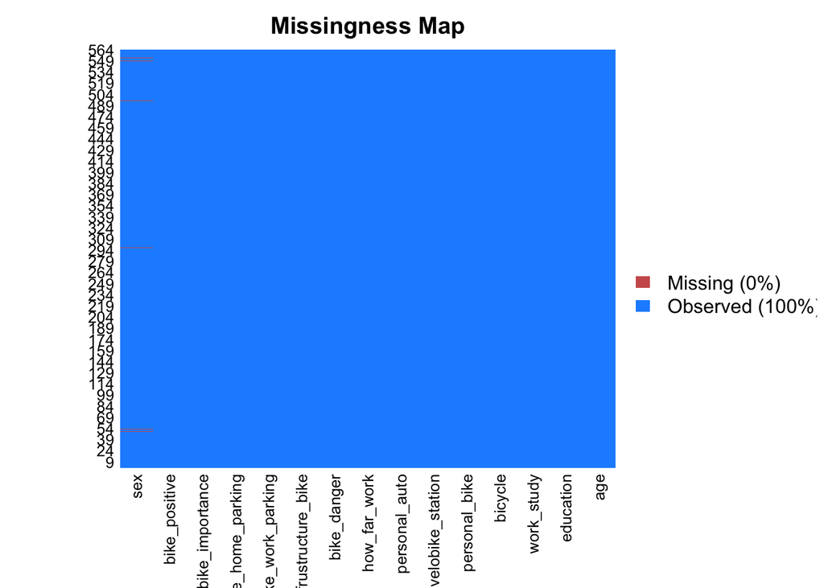

```r
missmap(regr)
```

Все эти пропущенные значения, находятся в переменной пола, поскольку в опросе изначально предполагался выбор “другого”, который мы не будем учитывать в нашем анализе

```r
regr <- na.omit(regr)
```

Описательные статистики:

```r
describe(regr)
```

| vars | n | mean | sd | median | trimmed | mad | min | max | range | skew | kurtosis | se |
| --- | --- | --- | --- | --- | --- | --- | --- | --- | --- | --- | --- | --- |
| 1 | 558 | 1.7 | 0.46 | 2 | 1.75 | 0 | 1 | 2 | 1 | -0.856 | -1.27 | 0.0195 |
| 2 | 558 | 38.3 | 9.85 | 38 | 38.3 | 8.9 | 18 | 69 | 51 | 0.0707 | 0.17 | 0.417 |
| 3 | 558 | 1.62 | 1.19 | 1 | 1.34 | 0 | 1 | 6 | 5 | 2.3 | 4.95 | 0.0503 |
| 4 | 558 | 3.71 | 1.01 | 4 | 3.91 | 0 | 1 | 5 | 4 | -1.87 | 2.6 | 0.0429 |
| 5 | 558 | 1.54 | 0.499 | 2 | 1.55 | 0 | 1 | 2 | 1 | -0.158 | -1.98 | 0.0211 |
| 6 | 558 | 1.63 | 0.482 | 2 | 1.67 | 0 | 1 | 2 | 1 | -0.557 | -1.69 | 0.0204 |
| 7 | 558 | 1.53 | 0.5 | 2 | 1.54 | 0 | 1 | 2 | 1 | -0.115 | -1.99 | 0.0212 |
| 8 | 558 | 1.66 | 0.472 | 2 | 1.71 | 0 | 1 | 2 | 1 | -0.697 | -1.52 | 0.02 |
| 9 | 558 | 2.32 | 1.27 | 2 | 2.27 | 1.48 | 1 | 4 | 3 | 0.207 | -1.65 | 0.0538 |
| 10 | 558 | 7.17 | 2.42 | 8 | 7.42 | 2.97 | 1 | 10 | 9 | -0.686 | -0.347 | 0.102 |
| 11 | 558 | 3.4 | 2.63 | 3 | 3.01 | 2.97 | 1 | 10 | 9 | 0.96 | -0.117 | 0.111 |
| 12 | 558 | 5.24 | 3.52 | 5 | 5.17 | 5.93 | 1 | 10 | 9 | 0.122 | -1.57 | 0.149 |
| 13 | 558 | 3.38 | 3.09 | 2 | 2.87 | 1.48 | 1 | 10 | 9 | 1.08 | -0.273 | 0.131 |
| 14 | 558 | 5.12 | 3.2 | 5 | 5.02 | 4.45 | 1 | 10 | 9 | 0.138 | -1.33 | 0.135 |
| 15 | 558 | 6.37 | 3.26 | 7 | 6.59 | 4.45 | 1 | 10 | 9 | -0.44 | -1.22 | 0.138 |

Посмотрим на половозрастное распределение респондентов:

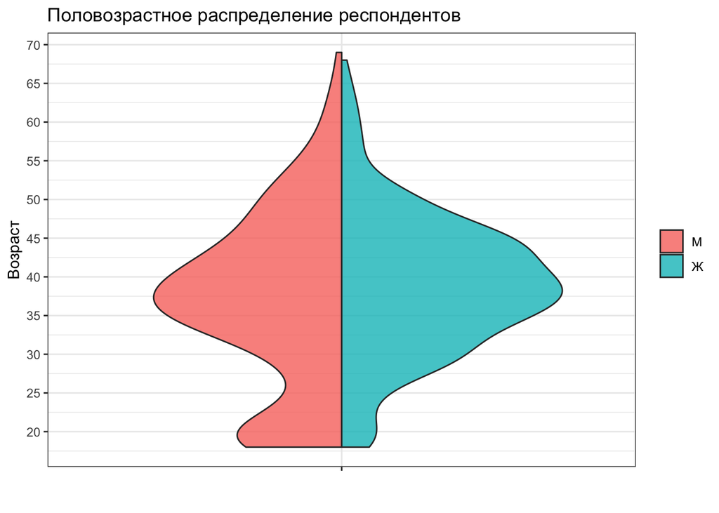

```r
ggplot(data = regr, aes(x = "", y = age, group = sex, fill = sex)) +
  geom_split_violin(alpha = 0.8) +
  scale_y_continuous(name = 'Возраст', breaks=seq(0, 70, 5)) +
  scale_x_discrete(name = '')+
  scale_colour_discrete(labels='пол')+
  ggtitle('Половозрастное распределение респондентов')+
  scale_fill_discrete(labels=c("М","Ж")) +
  guides(fill=guide_legend(title=NULL)) +
  theme_bw()
```

Мы видим, что наибольшее количетсво респондентов сконцентрировано вокруг 35 - 45 лет, из которых большинство женщин. Также в области до 25 лет, мы видим преобладание респондентов мужского пола.

Рассмотрим зависимость возраста и “катания” на велосипеде

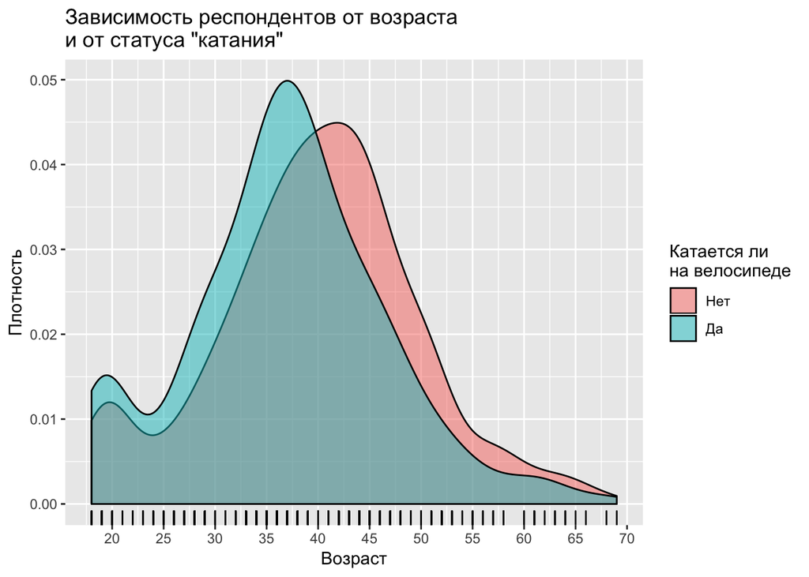

```r
ggplot(data = regr, aes(x = age, group = bicycle, fill = bicycle)) +
  geom_density(alpha = 0.5) + geom_rug() +
  scale_x_continuous(name = 'Возраст', breaks = seq(15, 75, 5))+
  scale_y_continuous(name = 'Плотность') +
  ggtitle('Зависимость респондентов от возраста \nи от статуса "катания"')+
  scale_fill_discrete(labels=c("Нет","Да")) +
  guides(fill=guide_legend(title='Катается ли \nна велосипеде'))
```

Исходя из данного графика, мы видим, что в принципе данные распределения почти накладываются друг на други, с небольшим смещением некатающихся респондентов в сторону большего возраста.

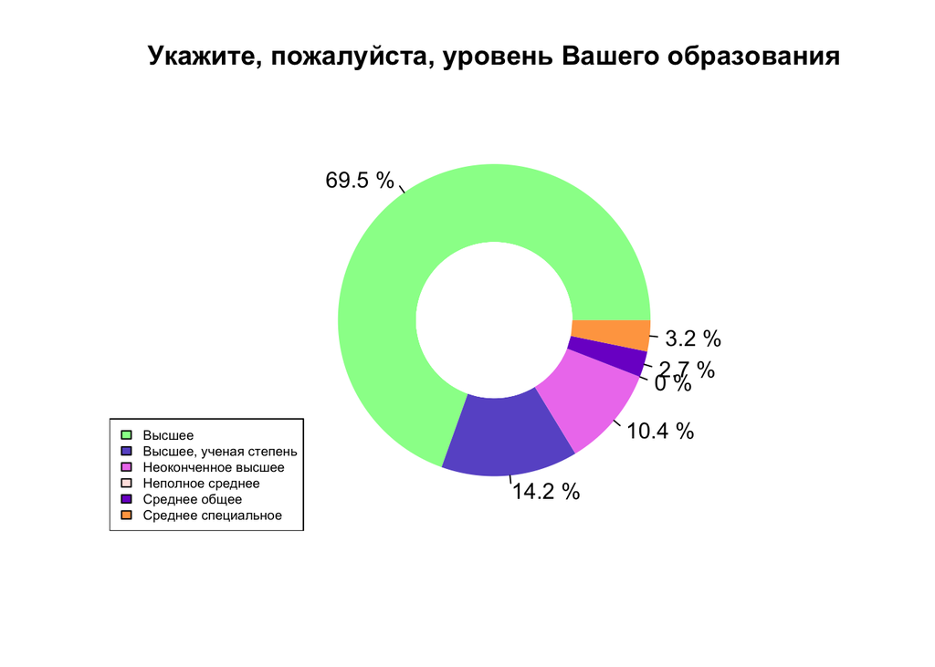

```r
colors2 <- c('palegreen', 'slateblue', 'violet', 'mistyrose', 'purple3', 'tan1', 'aquamarine')
labs2 = c("Высшее", "Высшее, ученая степень", "Неоконченное высшее", "Неполное среднее", 'Среднее общее', 'Среднее специальное')
doughnut(as.numeric(table(regr$education)),
    col = colors2,
    labels = paste(round(as.numeric(table(regr$education))/sum(as.numeric(table(regr$education))), 3) * 100, "%", sep = " "),
    main = 'Укажите, пожалуйста, уровень Вашего образования',
    inner.radius = 0.4)
legend("bottomleft", labs2, cex = 0.6, fill = colors2)
```

Исходя из этого графика, мы видим процентное соотношение в степени образования респондентов:

Большая часть (почти 70%) имеет высшее образование, а следующая по массовости группа - ученая степень

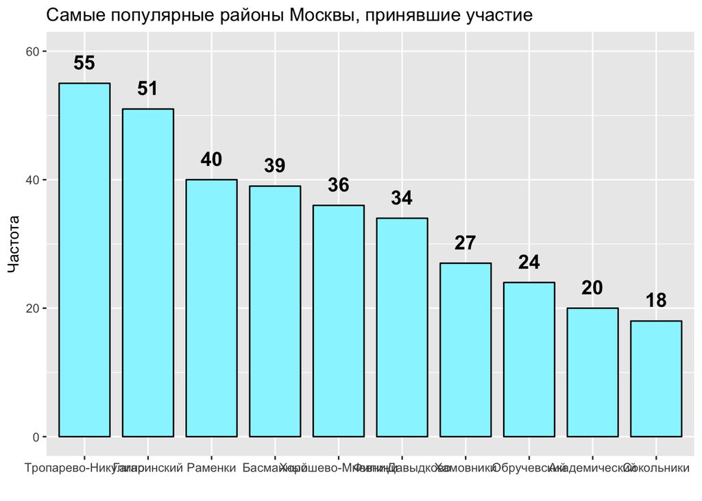

```r
distr <- as.data.frame(table(df$district)[table(df$district)>15])
distr %>% arrange(desc(Freq)) -> distr

ggplot(data=distr,
       aes(x=Var1, y=Freq)) +
  geom_bar(colour="black", fill="cadetblue1", width=.8, stat="identity") +
  geom_text(aes(label=Freq), vjust=-1, size=5, colour = 'black', fontface = 'bold') +
  scale_x_discrete(limits=c('тропарево-никулино',
                            'гагаринский',
                            'раменки',
                            'басманный',
                            'хорошево-мневники',
                            'фили-давыдково',
                            'хамовники',
                            'обручевский',
                            'академический',
                            'сокольники'),
                   labels = c('Тропарево-Никулино',
                            'Гагаринский',
                            'Раменки',
                            'Басманный',
                            'Хорошево-Мневники',
                            'Фили-Давыдково',
                            'Хамовники',
                            'Обручевский',
                            'Академический',
                            'Сокольники')) +
  scale_y_continuous(limits = c(0, 60)) +
  xlab("") + ylab("Частота") +
  ggtitle("Самые популярные районы Москвы, принявшие участие")
```

На данном графике, мы видим районы, в которых проживаем максимальное количество респондентов (>15)

Проверим зависимость между возрастом и наличием автомобиля:

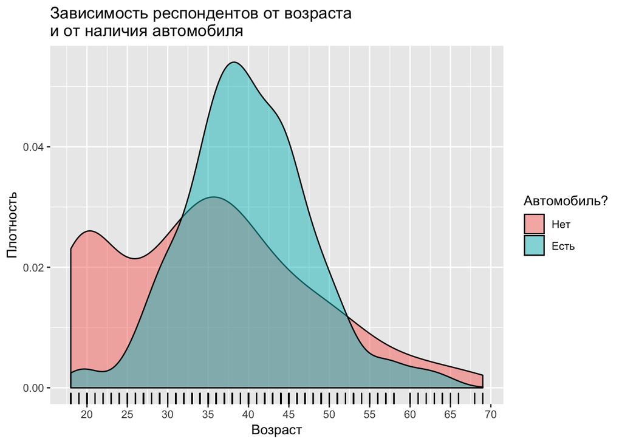

```r
ggplot(data = regr, aes(x = age, group = personal_auto, fill = personal_auto)) +
  geom_density(alpha = 0.5) + geom_rug()+
  scale_x_continuous(name = 'Возраст', breaks = seq(15, 75, 5))+
  scale_y_continuous(name = 'Плотность') +
  ggtitle('Зависимость респондентов от возраста \nи от наличия автомобиля')+
  scale_fill_discrete(labels=c("Нет","Есть")) +
  guides(fill=guide_legend(title='Автомобиль?'))
```

Как мы видим, данные распределения довольно плохо накладываются друг на друга: автомобиль есть преимущественно у населения в возрасте от 30 до 50 лет.

Проверим гипотезу о равенстве возрастов относительно наличия автомобиля

```r
t.test(data = regr, age ~ personal_auto)
```

```
##
##  Welch Two Sample t-test
##
## data:  age by personal_auto
## t = -4.8847, df = 264.17, p-value = 1.797e-06
## alternative hypothesis: true difference in means is not equal to 0
## 95 percent confidence interval:
##  -6.785362 -2.886662
## sample estimates:
## mean in group 0 mean in group 1
##        35.05348        39.88949
```

Соответсвенно, исходя из того, p-value меньше чем конвенциональное значение, мы можем сделать вывод о том, что средние в двух подвыборка неравны.

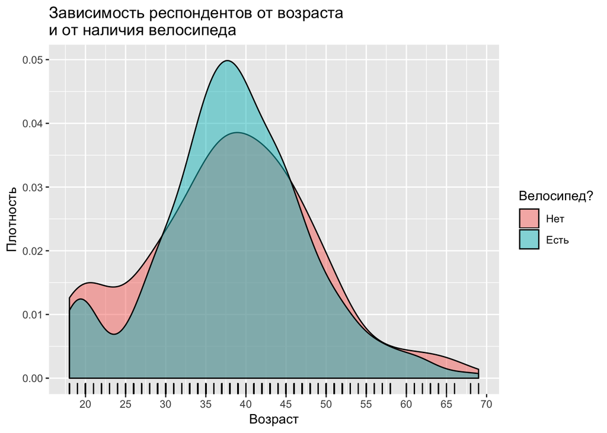

```r
ggplot(data = regr, aes(x = age, group = personal_bike, fill = personal_bike)) +
  geom_density(alpha = 0.5) + geom_rug() +
  scale_x_continuous(name = 'Возраст', breaks = seq(15, 75, 5))+
  scale_y_continuous(name = 'Плотность') +
  ggtitle('Зависимость респондентов от возраста \nи от наличия велосипеда')+
  scale_fill_discrete(labels=c("Нет","Есть")) +
  guides(fill=guide_legend(title='Велосипед?'))
```

Соответственно, мы видим, что в приниципе распределения похожи друг на друга, тем не менее, в возрасте от 30 до 40 больше респондентов, у которых есть велосипед

Проверим гипотезу о равенстве возрастов относительно владения личным велосипедом.

```r
t.test(data = regr, age ~ personal_bike)
```

```
##
##  Welch Two Sample t-test
##
## data:  age by personal_bike
## t = -0.47227, df = 380.1, p-value = 0.637
## alternative hypothesis: true difference in means is not equal to 0
## 95 percent confidence interval:
##  -2.187851  1.340393
## sample estimates:
## mean in group 0 mean in group 1
##        38.00000        38.42373
```

Соотвественно, исходя из довольно большого p-value, мы не можем отвергнуть нулевую гипотезу о равенстве средних, следовательно средний возраст у тех, у кого есть личный велосипед и у тех, у кого нет, не отличается.

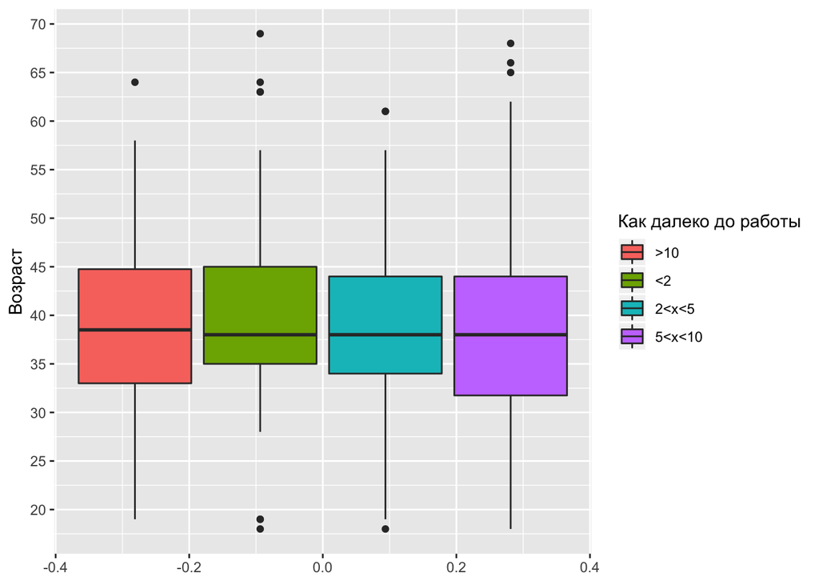

```r
ggplot(data = regr, aes(y = age, group = how_far_work, fill = how_far_work)) +
  geom_boxplot()+
  scale_y_continuous(name = 'Возраст', breaks = seq(15, 75, 5))+
  guides(fill=guide_legend(title='Как далеко до работы'))
```

Согласно представленному графику, мы видим, что средний возраст в каждой из категории примерно равен, а также что в каждой из категорий мы имеем выбросы по верхнему возрасту

Проверим гипотезу относительно равности возраста в разных категориях дистанции до работы

```r
anova.res <- aov(data = regr, age ~ how_far_work)
summary(anova.res)
```

```
##               Df Sum Sq Mean Sq F value Pr(>F)
## how_far_work   3    356  118.67   1.225    0.3
## Residuals    554  53676   96.89
```

Таким образом, мы видим, что p-value больше конвенционального значения, следовательно в каждой из подвыборках равный средний возраст

Посмотрим на восприятие велосипедистов в Москве:

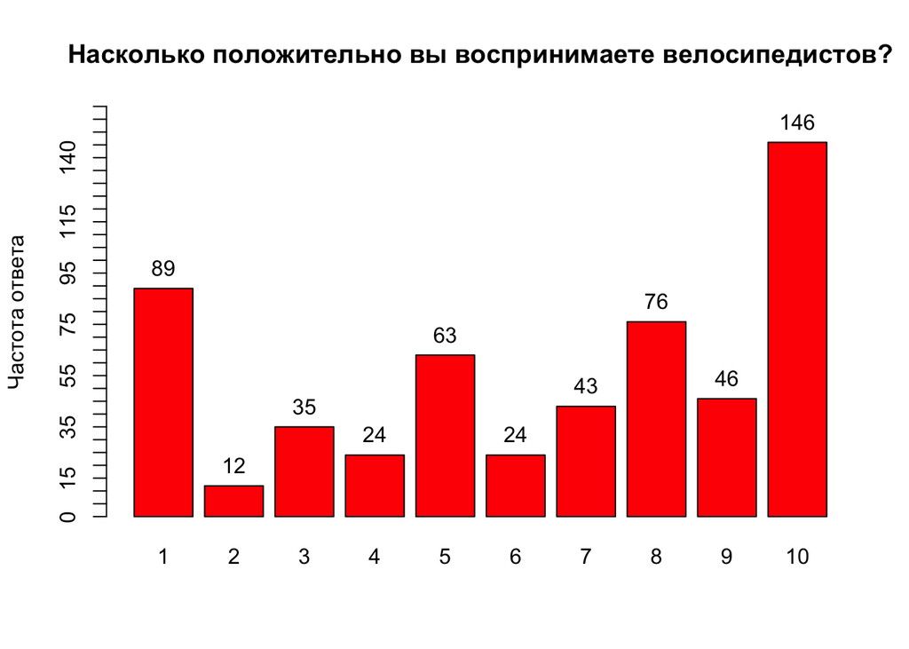

```r
pl <- barplot(table(regr$bike_positive),
              main = "Насколько положительно вы воспринимаете велосипедистов?",
              col = "red",
              ylim = c(0, 160),
              ylab = "Частота ответа",
              axes = FALSE)
axis(2, at = seq(from = 0, to = 160, by = 5))
text(x = pl, y = table(regr$bike_positive), labels = table(regr$bike_positive), pos = 3)
```

Мы можем посмотреть на корреляцию между интервальными переменными:

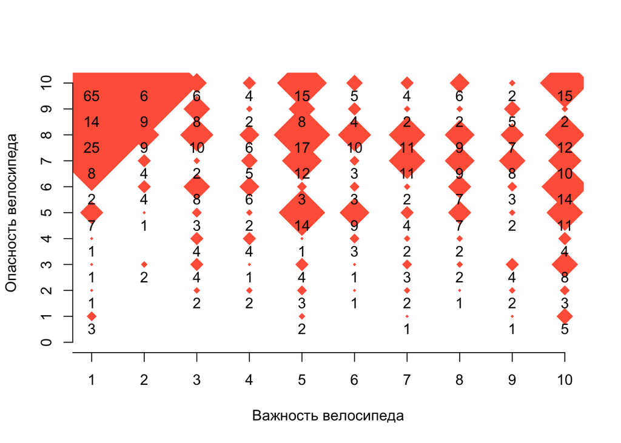

```r
AA <- xyTable(df$bike_importance, df$bike_danger)
coeff_bigger=0.5
plot(AA$x, AA$y,
     cex=AA$number*coeff_bigger,
     pch=18,
     col='tomato',
     xlab= "Важность велосипеда",
     ylab="Опасность велосипеда",
     xlim=c(1,10),
     ylim=c(0,10),
     axes = F); text(AA$x,
                        AA$y,
                        AA$number,
                        cex = 1,
                        pos = 1,
                        col = "black")
axis(1, at = seq(from = 0, to = 10, by = 1))
axis(2, at = seq(from = 0, to = 10, by = 1))
```

Как мы видим, тут можно наблюдать видимую отрицательную зависимость меду важностью велосипеда и опасностью велосипеде

Анализ: построение logit модели

```r
regr_logit <- glm(bicycle ~ (.), family = binomial, data = regr)
summary(regr_logit)
```

```
##
## Call:
## glm(formula = bicycle ~ (.), family = binomial, data = regr)
##
## Deviance Residuals:
##     Min       1Q   Median       3Q      Max
## -2.6549  -0.6211   0.2065   0.6096   2.4693
##
## Coefficients:
##                             Estimate Std. Error z value Pr(>|z|)
## (Intercept)                -1.068674   1.053232  -1.015  0.31027
## sex1                       -0.287918   0.287503  -1.001  0.31661
## age                        -0.050398   0.016850  -2.991  0.00278 **
## educationhigher, phd        0.441936   0.357663   1.236  0.21660
## educationuncomplete higher  0.427708   0.565721   0.756  0.44962
## educationmiddle common     -0.113745   0.783209  -0.145  0.88453
## educationmiddle special     0.944269   0.715414   1.320  0.18687
## work_studyДекрет           -0.950967   0.758773  -1.253  0.21010
## work_studyПенсионер         2.806338   1.578103   1.778  0.07535 .
## work_studyРаботает         -0.048010   0.406788  -0.118  0.90605
## work_studyУчится           -1.083516   0.762815  -1.420  0.15549
## personal_bike1              2.117609   0.263599   8.033 9.48e-16 ***
## velobike_station1           0.123714   0.243930   0.507  0.61204
## personal_auto1              0.388597   0.291790   1.332  0.18293
## how_far_work<2              0.159627   0.406547   0.393  0.69458
## how_far_work2<x<5           0.152845   0.342391   0.446  0.65531
## how_far_work5<x<10          0.101575   0.298924   0.340  0.73401
## bike_danger                -0.129227   0.061178  -2.112  0.03466 *
## infrustructure_bike        -0.001213   0.054988  -0.022  0.98239
## bike_work_parking           0.034803   0.038198   0.911  0.36223
## bike_home_parking          -0.020757   0.044272  -0.469  0.63917
## bike_importance             0.389181   0.053573   7.264 3.75e-13 ***
## bike_positive               0.077674   0.049007   1.585  0.11298
## ---
## Signif. codes:  0 '***' 0.001 '**' 0.01 '*' 0.05 '.' 0.1 ' ' 1
##
## (Dispersion parameter for binomial family taken to be 1)
##
##     Null deviance: 770.08  on 557  degrees of freedom
## Residual deviance: 456.60  on 535  degrees of freedom
## AIC: 502.6
##
## Number of Fisher Scoring iterations: 5
```

При полной спецификации модели, мы видим, что некоторые из наших параметров оказались значимыми, как например наличие личного велосипеда. Тем не менее, мы видим, что коэффициент при параметр восприятия инфраструктуры оказался незначимым, и очень маленькими, что говорит об отсутствии связи между вероятностью того, что человек будет кататсья на велосипеде и развитостью инфраструктуры.

Также мы видим, что уровень образования оказался не значимым.

Найдем самую экономную модель исходя из AIC

```r
regr.AIC <- step(regr_logit)
```

```
## Start:  AIC=502.6
## bicycle ~ (sex + age + education + work_study + personal_bike +
##     velobike_station + personal_auto + how_far_work + bike_danger +
##     infrustructure_bike + bike_work_parking + bike_home_parking +
##     bike_importance + bike_positive)
##
##                       Df Deviance    AIC
## - how_far_work         3   456.89 496.89
## - education            4   460.34 498.34
## - infrustructure_bike  1   456.60 500.60
## - bike_home_parking    1   456.82 500.82
## - velobike_station     1   456.86 500.86
## - bike_work_parking    1   457.44 501.44
## - sex                  1   457.61 501.61
## - work_study           4   464.10 502.10
## - personal_auto        1   458.39 502.39
## <none>                     456.60 502.60
## - bike_positive        1   459.08 503.08
## - bike_danger          1   461.11 505.11
## - age                  1   465.82 509.82
## - bike_importance      1   522.10 566.10
## - personal_bike        1   532.35 576.35
##
## Step:  AIC=496.89
## bicycle ~ sex + age + education + work_study + personal_bike +
##     velobike_station + personal_auto + bike_danger + infrustructure_bike +
##     bike_work_parking + bike_home_parking + bike_importance +
##     bike_positive
##
##                       Df Deviance    AIC
## - education            4   460.45 492.45
## - infrustructure_bike  1   456.90 494.90
## - bike_home_parking    1   457.11 495.11
## - velobike_station     1   457.25 495.25
## - bike_work_parking    1   457.65 495.65
## - sex                  1   457.81 495.81
## - work_study           4   464.55 496.55
## - personal_auto        1   458.63 496.63
## <none>                     456.89 496.89
## - bike_positive        1   459.37 497.37
```

[output cut: 126 more lines]

```
## <none>                 471.70 483.70
## - age              1   475.49 485.49
## - bike_danger      1   478.72 488.72
## - bike_importance  1   540.28 550.28
## - personal_bike    1   555.31 565.31
##
## Step:  AIC=483.29
## bicycle ~ age + personal_bike + bike_danger + bike_importance
##
##                   Df Deviance    AIC
## <none>                 473.29 483.29
## - age              1   477.60 485.60
## - bike_danger      1   482.28 490.28
## - personal_bike    1   559.65 567.65
## - bike_importance  1   591.83 599.83
```

```r
summary(regr.AIC)
```

```
##
## Call:
## glm(formula = bicycle ~ age + personal_bike + bike_danger + bike_importance,
##     family = binomial, data = regr)
##
## Deviance Residuals:
##     Min       1Q   Median       3Q      Max
## -2.4605  -0.6652   0.2439   0.6564   2.5407
##
## Coefficients:
##                 Estimate Std. Error z value Pr(>|z|)
## (Intercept)     -1.15730    0.59956  -1.930  0.05358 .
## age             -0.02609    0.01265  -2.063  0.03908 *
## personal_bike1   2.16620    0.25357   8.543  < 2e-16 ***
## bike_danger     -0.15302    0.05172  -2.959  0.00309 **
## bike_importance  0.41356    0.04343   9.523  < 2e-16 ***
## ---
## Signif. codes:  0 '***' 0.001 '**' 0.01 '*' 0.05 '.' 0.1 ' ' 1
##
## (Dispersion parameter for binomial family taken to be 1)
##
##     Null deviance: 770.08  on 557  degrees of freedom
## Residual deviance: 473.29  on 553  degrees of freedom
## AIC: 483.29
##
## Number of Fisher Scoring iterations: 5
```

```r
itog <- regr.AIC
```

```r
summ(itog, robust = T, exp = T, vifs = TRUE, scale = T, center = T)
```

```
## MODEL INFO:
## Observations: 558
## Dependent Variable: bicycle
## Type: Generalized linear model
##   Family: binomial
##   Link function: logit
##
## MODEL FIT:
## χ²(4) = 296.79, p = 0.00
## Pseudo-R² (Cragg-Uhler) = 0.55
## Pseudo-R² (McFadden) = 0.39
## AIC = 483.29, BIC = 504.91
##
## Standard errors: Robust, type = HC3
## -----------------------------------------------------------------------
##                         exp(Est.)   2.5%   97.5%   z val.      p    VIF
## --------------------- ----------- ------ ------- -------- ------ ------
## (Intercept)                  0.32   0.21    0.48    -5.52   0.00
## age                          0.77   0.61    0.97    -2.18   0.03   1.11
## personal_bike                8.73   5.32   14.31     8.58   0.00   1.10
## bike_danger                  0.69   0.54    0.89    -2.91   0.00   1.08
## bike_importance              3.75   2.83    4.99     9.13   0.00   1.06
## -----------------------------------------------------------------------
##
## Continuous predictors are mean-centered and scaled by 1 s.d.
```

Исходя из данной спецификации модели, мы видим, что все переменные оказались значимыми, даже при применении робастных ошибок HC3

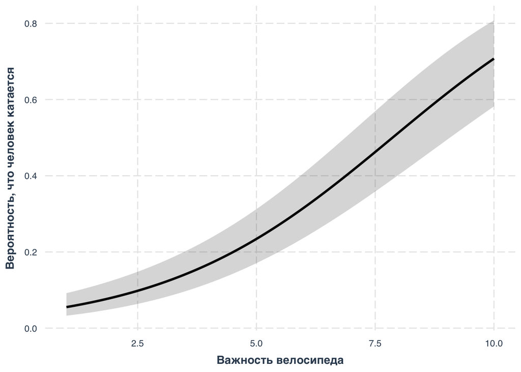

```r
effect_plot(itog, pred = bike_importance, interval = TRUE,
            x.label = 'Важность велосипеда',
            y.label = 'Вероятность, что человек катается')
```

Мы можем наблюдать положительное влияние важности велосипеда для респондента на вероятность катания, которая значительно растет на протяжении всего отрезка

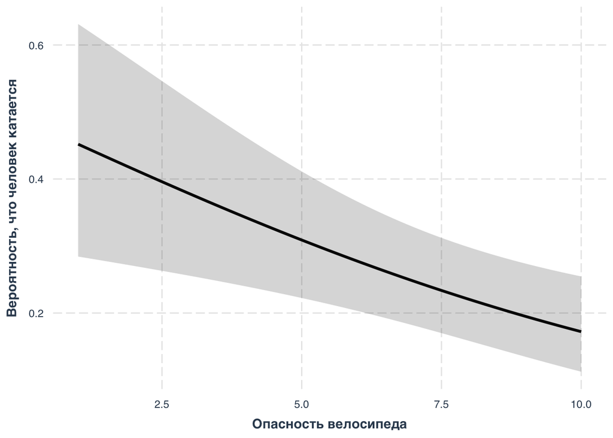

```r
effect_plot(itog, pred = bike_danger, interval = TRUE,
            x.label = 'Опасность велосипеда',
            y.label = 'Вероятность, что человек катается')
```

Исходя из данного графика мы видим отрицательное влияние опасности велосипеда на вероятность того, что человек будет кататься на велосипеде

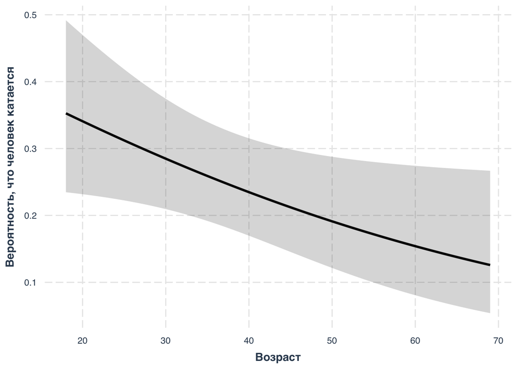

```r
effect_plot(itog, pred = age, interval = TRUE,
            x.label = 'Возраст',
            y.label = 'Вероятность, что человек катается')
```

Мы наблюдаем отрицательное влияние возраста на вероятность того, что человек будет кататься на велосипеде

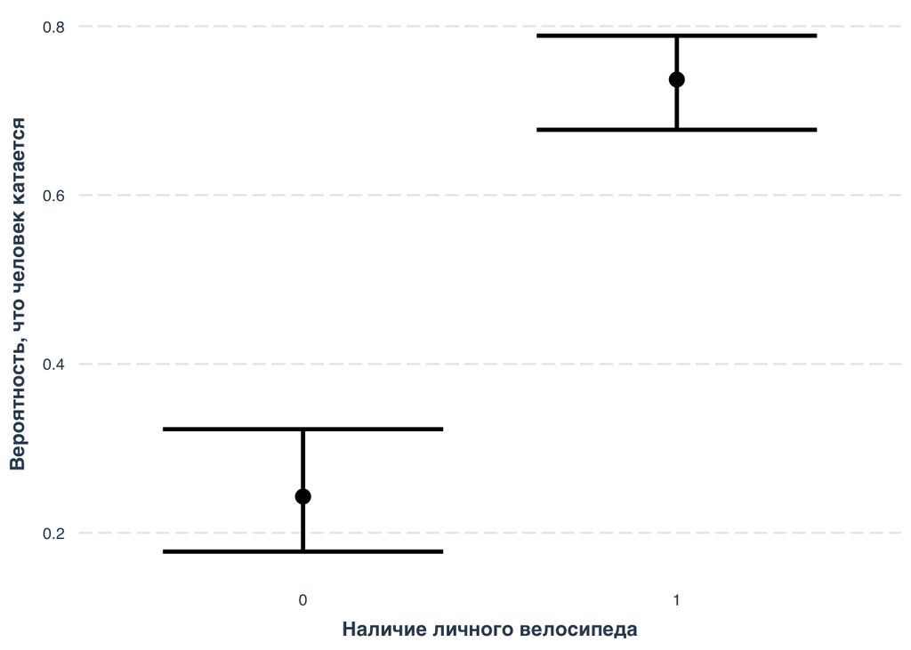

```r
effect_plot(itog, pred = personal_bike, interval = TRUE,
            x.label = 'Наличие личного велосипеда',
            y.label = 'Вероятность, что человек катается')
```

Здесь мы можем видеть, значительный прирост в вероятности при переходе от категории отсутствия личного велосипеда к его наличию.

Доверительные интервалы получившихся коэффициентов

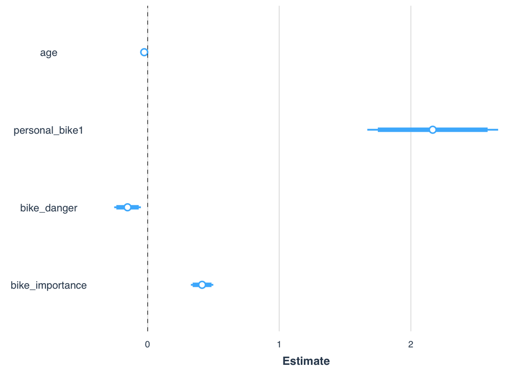

```r
plot_summs(itog, inner_ci_level = .9)
```

Доверительные интервалы для разных типов робастных ошибок

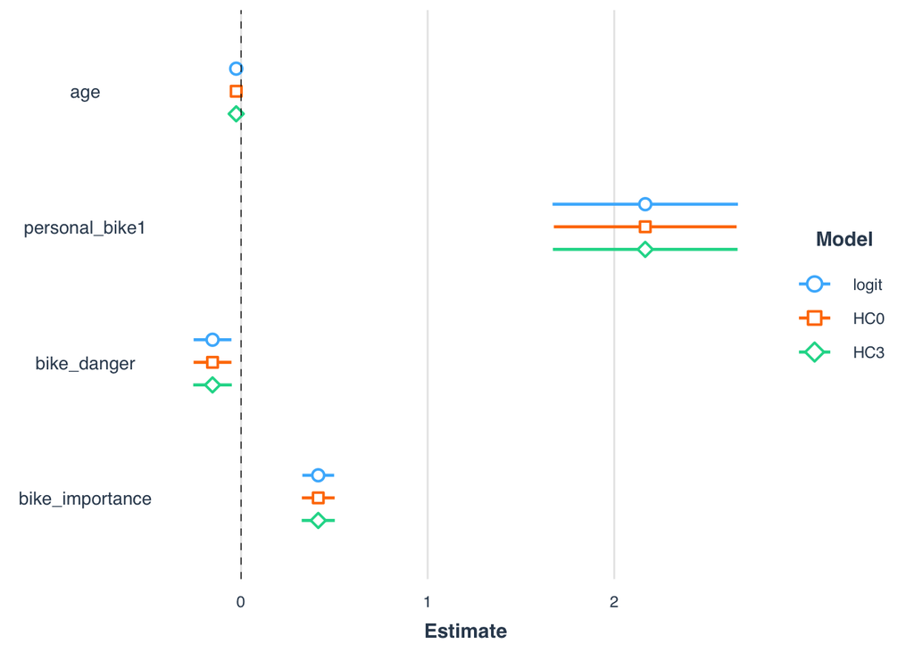

```r
plot_summs(itog, itog, itog, robust = list(FALSE, "HC0", "HC3"),
           model.names = c("logit", "HC0", "HC3"))
```

## Главные выводы:

Исходя из построенное модели мы можем сделать выводы о:

- Сильном положительном влиянии показателя важности велосипеда для респондента на вероятность его катания.
- Отрицательной взаимосвязи между восприятием опасности велосипедной дороги до работы и вероятности его катания.
- Значительной роли наличия велосипеда у респондента, которая значительно увеличивают вероятность езды на велосипеде.
- Отрицательном влиянии возраста респондента на вероятность езды на велосипеде.